# Analysis of SARS-CoV-2 Survival Times

## Introduction

The goal for this analysis is to evaluate survival of SARS-CoV-2 on different surfaces. We have experimental data, in triplicate, for different variants, humidity levels, and surfaces. The relevant baseline period is ‘0 hours dry’. Note that replicates are not longitundinal (i.e., replate 1B is not from same tile as 2B), so they should be treated independently.

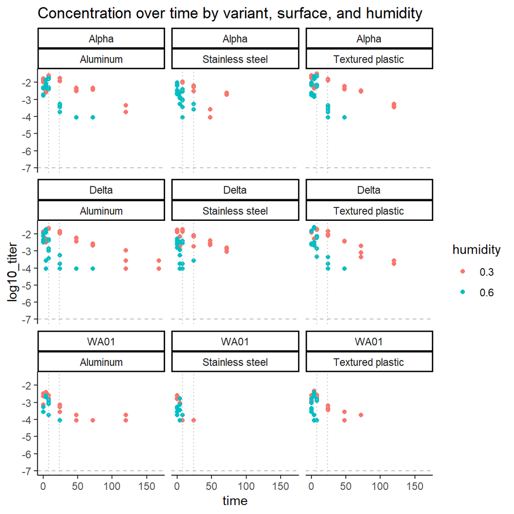

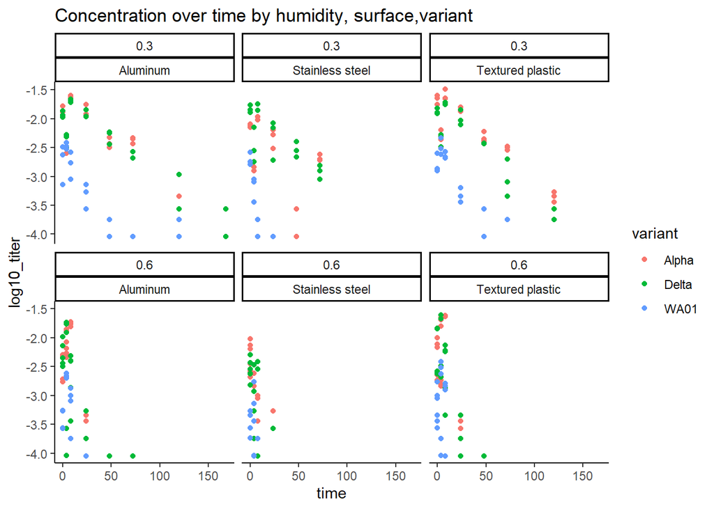

## Regression models

Half life for plastic, steel not significantly different than aluminum

```
## # A tibble: 3 x 2
##   surface         HalfLife
##   <chr>           <chr>
## 1 Aluminum        26 (95%CI:22, 32)
## 2 Stainless Steel 29 (95%CI:19, 56)
## 3 Plastic         20 (95%CI:17, 25)
```

Differences by variant not significant

|  | variant | humidity | HalfLife |
| --- | --- | --- | --- |
| 1 | Alpha | 30 | 30 (95%CI:22, 48) |
| 2 | Alpha | 60 | 8 (95%CI:7, 9) |
| 3 | Delta | 30 | 25 (95%CI:20, 33) |
| 4 | Delta | 60 | 9 (95%CI:8, 11) |
| 5 | WA-01 | 30 | 22 (95%CI:17, 31) |
| 6 | Wa-01 | 60 | 12 (95%CI:-435, 408) |

|  | humidity | HalfLife |
| --- | --- | --- |
| 1 | 30 | 24 (95%CI:21, 28) |
| 2 | 60 | 8 (95%CI:7, 9) |

## Survival model

Failure time is time of censoring

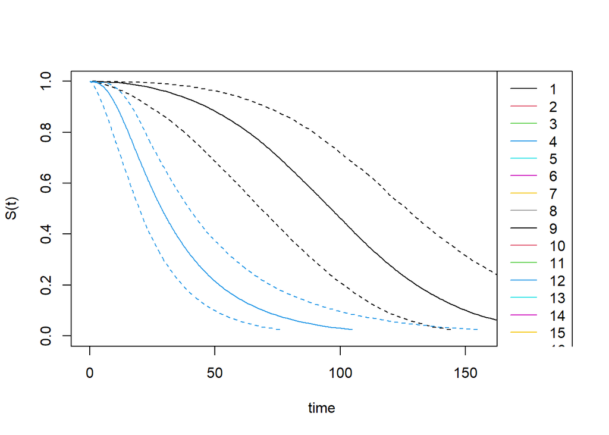

## Side note: Exploring stats to combine dilutions

Conclusion, take a weighted average of the concentrations, with the weight being proportional to the dilution. This is equivalent to the MLE estimate

```r
test <- c(4,5,60, 600)
```

without an offset, the max likelihood estimate is just the sample mean of the counts

```r
offset3 <- c(1,1,1,1)
mod3 <- glm(test ~ 1, family='poisson', offset=log(offset3))

exp(mod3$coefficients)
```

```
## (Intercept)
##      167.25
```

```r
mean(test)
```

```
## [1] 167.25
```

With an offset, the mean is the weighted mean of the rate is equal to the weighted average of the rate

```r
offset1 <- c(1,1,10,100)

mod1 <- glm(test ~ 1, family='poisson', offset=log(offset1))

exp(mod1$coefficients)
```

```
## (Intercept)
##    5.973214
```

```r
sum(test/offset1*offset1/sum(offset1)) #average, weighted by offset
```

```
## [1] 5.973214
```

ditto

```r
offset2 <- c(100,100,10,1)

df.test2 <- cbind.data.frame('y'=test, 'log_offset'=log(offset2))

mod2 <- glm(y ~ 1, family='poisson', offset=log_offset, data=df.test2)

exp(mod2$coefficients)
```

```
## (Intercept)
##    3.170616
```

```r
sum(test/offset2*offset2/sum(offset2))
```

```
## [1] 3.170616
```